# HW03

Philip Belov

December 5, 2015

First, let’s include all the necessary libraries we need:

```r
library(dplyr)
library(rpart)
library(rpart.plot)
```

Next, let’s set up the initial dataset:

```r
IncomeData <- read.csv("~/materials/minor/lab09/Income_Data.txt", header = F, col.names = c("income", "sex", "martial_status", "age", "edu", "ocupation", "living_time", "dual_incomes", "pers_in_house", "pers_in_house_under18", "householder_status", "type_of_home", "ethnic_cl", "lang"))

IncomeData <- within(IncomeData, {
  sex <- factor(sex)
  martial_status <- factor(martial_status)
  edu <- factor(edu)
  ocupation <- factor(ocupation)
  living_time <- factor(living_time)
  dual_incomes <- factor(dual_incomes)
  householder_status <- factor(householder_status)
  type_of_home <- factor(type_of_home)
  ethnic_cl <- factor(ethnic_cl)
  lang <- factor(lang)
  age <- ordered(age)
  pers_in_house <- ordered(pers_in_house)
  pers_in_house_under18 <- ordered(pers_in_house_under18)
})
```

Let’s try to build a tree. I decided to include all available parameters as independent variables as long as after conducting a few experiments I’ve noticed that if we select smaller number of independent variables then the performance of the model decreases.

```r
set.seed(1)
income.tree = rpart(income~., data = IncomeData, control = rpart.control(cp = 0.001), method = "anova")
income.tree.mod = rpart(income~., data = IncomeData, control = rpart.control(cp = 0.02), method = "anova")
min = which.min(income.tree$cptable[,"xerror"])
min.mod = which.min(income.tree.mod$cptable[,"xerror"])
```

Ok. Fine. It’s time to discover what does cp parameter stand as the value of control parameter of rpart function.

So, I’m going to look at values of errors using printcp command.

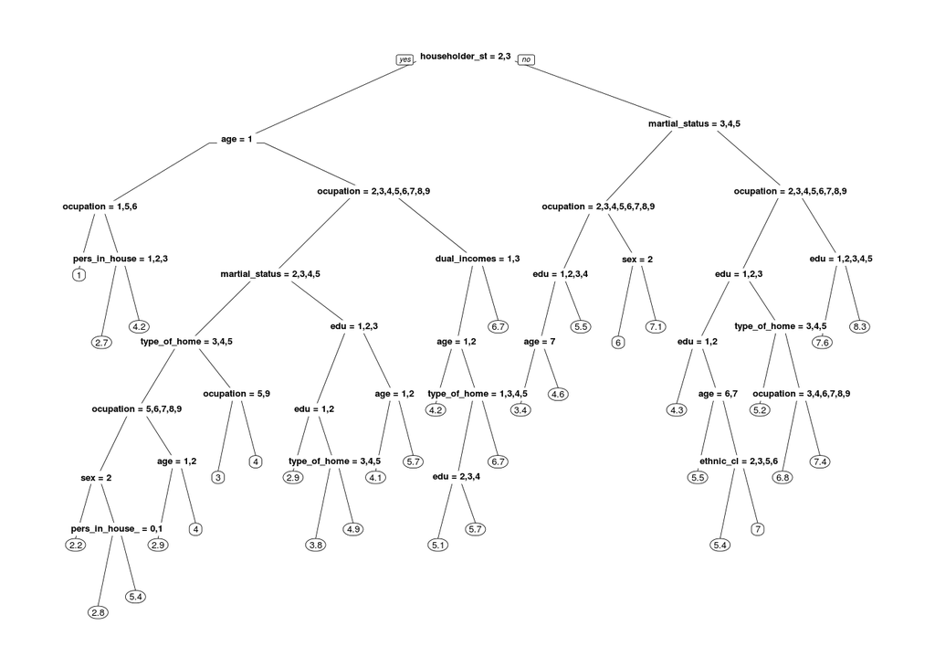

```r
prp(income.tree)
```

```r
printcp(income.tree)
```

```
##
## Regression tree:
## rpart(formula = income ~ ., data = IncomeData, method = "anova",
##     control = rpart.control(cp = 0.001))
##
## Variables actually used in tree construction:
##  [1] age                   dual_incomes          edu
##  [4] ethnic_cl             householder_status    martial_status
##  [7] ocupation             pers_in_house         pers_in_house_under18
## [10] sex                   type_of_home
##
## Root node error: 69179/8993 = 7.6925
##
## n= 8993
##
```

[output cut: 33 more lines]

In the first case the least cross-validation error (xerror) equals *0.5265244*, which is the place where it’d logical to prune the tree as long this value is minimum amongst the other cv errors (*cp = 0.001076*).

In the second case

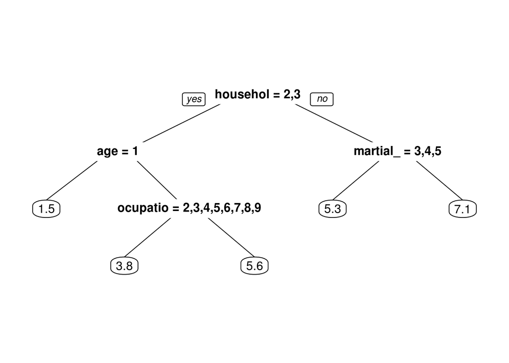

```r
prp(income.tree.mod)
```

```r
printcp(income.tree.mod)
```

```
##
## Regression tree:
## rpart(formula = income ~ ., data = IncomeData, method = "anova",
##     control = rpart.control(cp = 0.02))
##
## Variables actually used in tree construction:
## [1] age                householder_status martial_status
## [4] ocupation
##
## Root node error: 69179/8993 = 7.6925
##
## n= 8993
##
##         CP nsplit rel error  xerror      xstd
## 1 0.223922      0   1.00000 1.00023 0.0082594
## 2 0.080770      1   0.77608 0.77634 0.0088523
## 3 0.044728      2   0.69531 0.69572 0.0091816
## 4 0.030699      3   0.65058 0.65126 0.0093130
## 5 0.020000      4   0.61988 0.62070 0.0089342
```

We see that the minimum cv error is *0.6207007*, which is higher than in the first case (*cp = 0.02*).

It’d be nice to note that with cp=0.02 the number of used variables is significantly less than with cp=0.001; hence the tree is less complicated as well, because it actually has smaller amount of levels. Furthermore, the number of steps (decreasing the cp) taken is 32 in the first case, and only 5 in the second case. So, in my opinion, the second way of building a tree might be less accurate and I guess the fact that the minimum xerror in the first case is less than in the second case proves that. Also, I read documentation and found out that cp parameter is one of the parameters which control aspects of how the tree is fitted. According to docs, the overall R-squared increases by cp at each step, and the main role of the cp parameter is to save computing time by pruning off splits that are not worthwhile to be in our model. ***

Now let’s review our tree again:

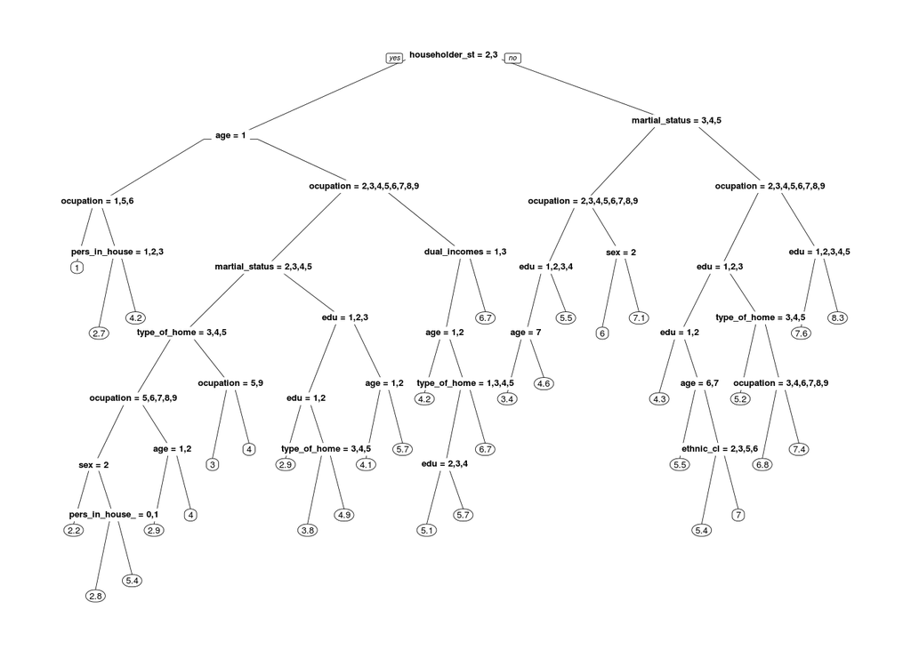

```r
prp(income.tree)
```

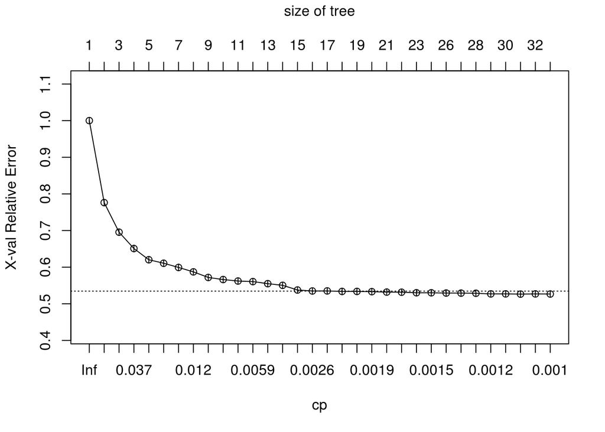

```r
plotcp(income.tree)
```

```r
printcp(income.tree)
```

```
Regression tree:
rpart(formula = income ~ ., data = IncomeData, method = "anova",
    control = rpart.control(cp = 0.001))

Variables actually used in tree construction:
 [1] age                   dual_incomes          edu
 [4] ethnic_cl             householder_status    martial_status
 [7] ocupation             pers_in_house         pers_in_house_under18
[10] sex                   type_of_home

Root node error: 69179/8993 = 7.6925

n= 8993

          CP nsplit rel error  xerror      xstd
```

[output cut: 32 more lines]

Let’s make a prediction and see how good it is:

```r
income.tree.pred=predict(income.tree, data = IncomeData, type="vector")
RMSE <- sqrt(mean((income.tree.pred-IncomeData$income)^2))
COR <- cor(x=income.tree.pred, y=IncomeData$income, method="spearman")
```

Now let’s prune our tree where cross-validation error is taking its minimum value and then see if it’s any better than the first model.

```r
ptree <- prune(income.tree, cp=income.tree$cptable[min,"CP"])
```

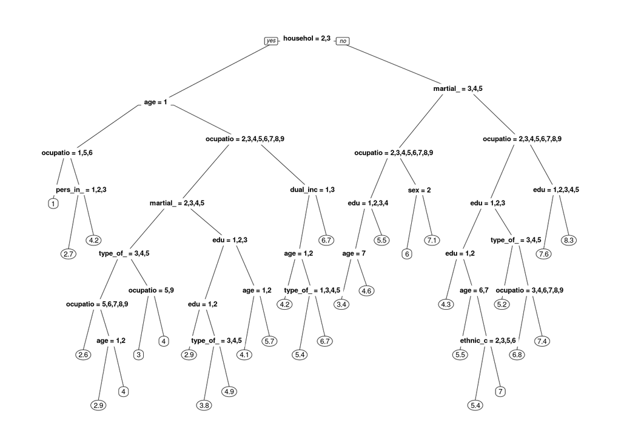

```r
prp(ptree)
```

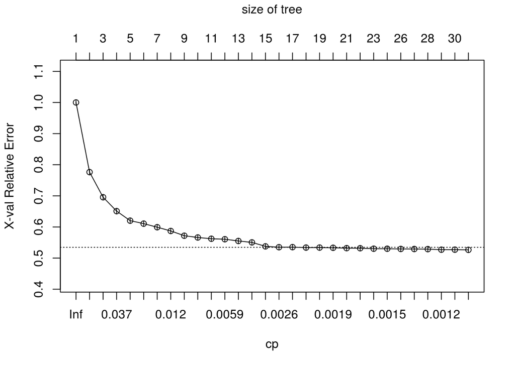

```r
plotcp(ptree)
```

```r
printcp(ptree)
```

```
Regression tree:
rpart(formula = income ~ ., data = IncomeData, method = "anova",
    control = rpart.control(cp = 0.001))

Variables actually used in tree construction:
 [1] age                dual_incomes       edu
 [4] ethnic_cl          householder_status martial_status
 [7] ocupation          pers_in_house      sex
[10] type_of_home

Root node error: 69179/8993 = 7.6925

n= 8993

          CP nsplit rel error  xerror      xstd
```

[output cut: 30 more lines]

```r
ptree.pred=predict(ptree, data = IncomeData, type="vector")
RMSE2 <- sqrt(mean((ptree.pred-IncomeData$income)^2))
COR2 <- cor(x=ptree.pred, y=IncomeData$income, method="spearman")
```

If we compare the RMSE of the first model which is *1.966269* with the second one *1.9725373*, it’s obvious that the first value is less than a second value, which leads to a conclusion that the first model (not pruned) is better than the model based on the pruned tree. Although, the difference is not that big, in my opinion. We can also look at the correlation between the predicted values and the values from the initial data set. In the first case correlation equals *0.6939795*, which is a little bit bigger than after pruning the tree: *0.6913496*. Which, again, leads to a conclusion that the first model performs better.

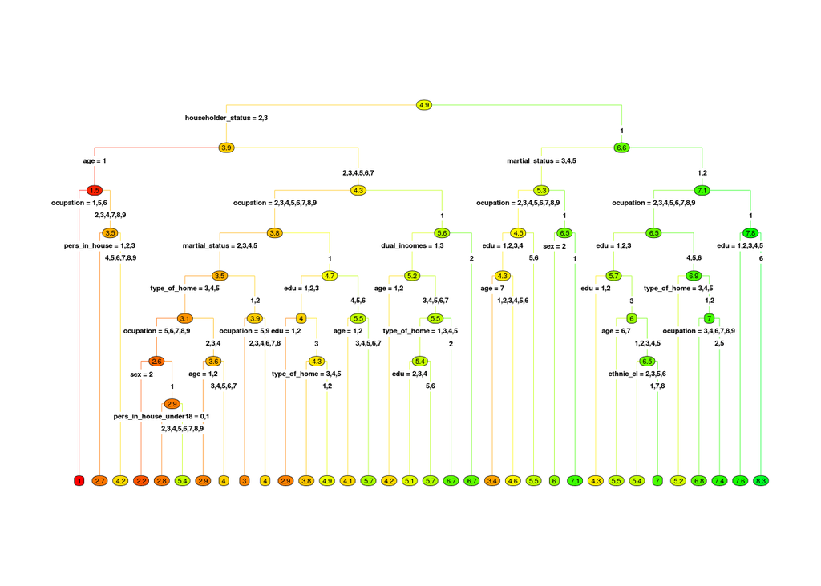

```r
set.seed(1)
income.tree = rpart(income~., data = IncomeData, control = rpart.control(cp = .001), method = "anova")
heat.tree(income.tree, type=4, varlen=0, faclen=0, fallen.leaves=TRUE)
```

If a person rent a household or lives with parents or family, his age is from 14 to 17 and his ocupation is professional/managerial or he’s a student at high school/college or a homemaker then the person’s income is less than $10k.

If a person owns and grad study then his annual income is around $60k.

Now, let’s assume that we have a person, whose householder status is ‘own’, sex is male (1), type of home is apartment (2), martial status is married (1), age is 26 (3), education is college graduate (5), ocupation is proffessional/managerial (1). Then, according to our tree, the annual income of such person is around $46k (7.6).

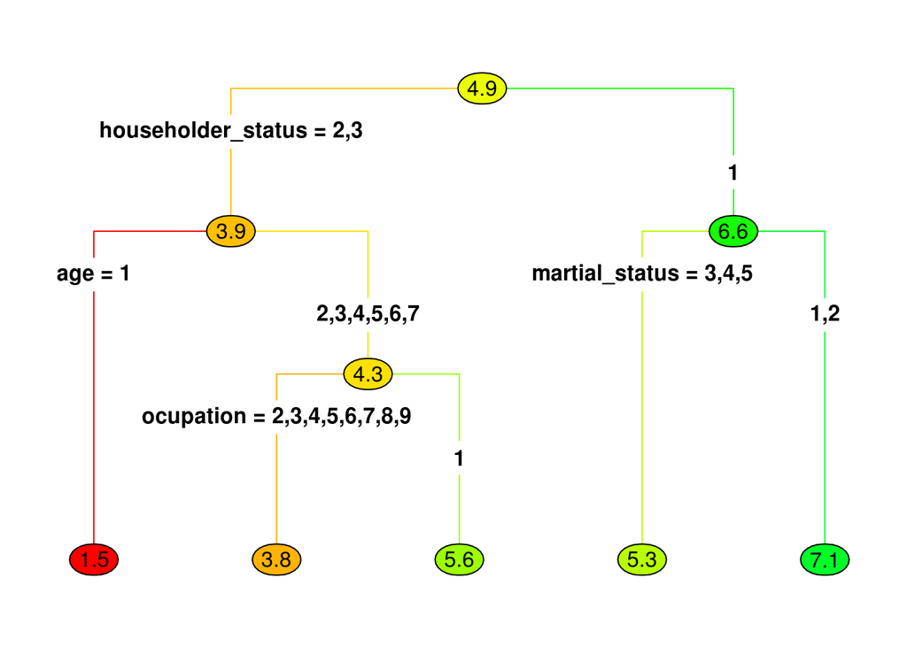

```r
income.tree = rpart(income~., data = IncomeData, control = rpart.control(cp = .02), method = "anova")
heat.tree(income.tree, type=4, varlen=0, faclen=0, fallen.leaves=TRUE)
```

**THANKS FOR READING MY HOMEWORK. HOPE YOU LIKED IT!**